# COVID-C1

DATA3888 | The University of Sydney

# 1 Executive Summary

The coronavirus (SARS-CoV-2) virus is life-threatening for certain individuals. This necessitates the development of omics-based risk calculators, which are able to predict disease progression based on a patient’s omics. Our team developed a [risk calculator](https://github.com/LionelYao/Covid_C1_shinyapp) integrating proteomics, metabolomics and transcriptomics by integrating data from different papers. The result is an adaptive risk calculator, whereby users can upload any combination of these three omics platforms, and receive predicted outcomes. The risk calculator also allows users to interactively explore the proteomics, metabolomics and transcriptomics data used in training.

Figure 1 provides an overview of our process. We first collected data, then we performed feature and classifier selection for each platform. We compared three methods of feature selection: moderated t-statistics, logFC and a PCA-based approach. We found that all three methods granted similar cross validation accuracy and recall for our classifiers.

Our final models are logistic regression models built on the clinical data, and the final prevalidated vectors for each platform. We built one such final model for each combination of platforms, giving 7 final models (see Figure 1, Final Models)

Our final models achieved cross-validation accuracies and recalls around 0.85 and 0.75 respectively (over 50-repetitions), with the exception of the transcriptomics-only model, which had 0.75 cross-validation accuracy and 0.54. Similar results were found when validating models using our test sets: most final models had accuracy around 0.9 and recall around 0.75. However, the transcriptomics model only had accuracy around 0.75 and recall around 0.44.

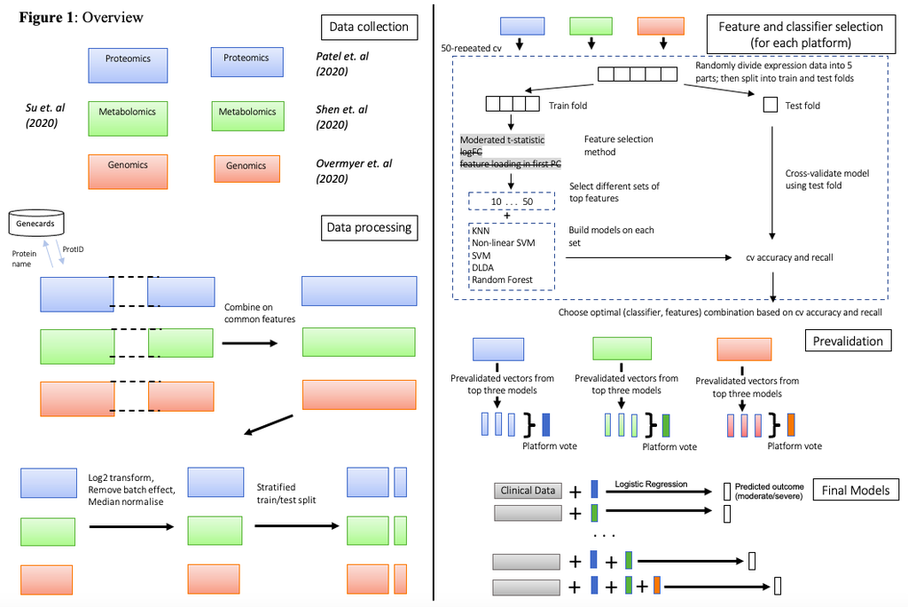

# 2 Background

The problem is to build an omics-based risk calculator to predict COVID-19 disease progression (moderate/severe). The motivation for the product is to identify severe outcomes and aid early intervention efforts.

Our approach has the following features:

- Our training data integrated Su et al. (2020), Patel et al. (2020), Shen et al. (2020) and Overmyer et al. (2021). A common difficulty in omics-based data analysis is *large p small n* - the problem of having many features, but few samples. Thus, combining papers gives a larger number of samples for each omics platform, hopefully allowing to better find trends.
- We experimented with different feature selection methods, such as moderated t-statistics, logFC, and a PCA-based approach. These are described in the method and results sections.
- We built a final model for each possible combination of proteomics, metabolomics and transcriptomics. Thus, for any combination of platforms that the user provides, our risk calculator is able to provide predictions, using the matching final model.

# 3 Methods

## 3.1 Data Collection

Our risk calculator utilises proteomics, metabolomics (expression from blood plasma and sera), and transcriptomics (rna-seq expression from PBMC). Su et al. provide proteomics, metabolomics and transcriptomics; Patel et al., Shen et al. and Overmyer et al. each provide proteomics, metabolomics and transcriptomics, respectively. Data sources are provided in the appendix, along with an overview here. For brevity, we shall subsequently refer to Su et al. as Su, likewise for other papers.

Su provided expression of about 500 proteomes, about 1000 metabolomes, and RNA-sequence expression (taken on the single-cell level over approximately 550000 cells, for each individual). Of the 265 samples, 110 were classified mild, 102 moderate, and 52 severe, according to the WHO ordinal scale. 1 observation did not record severity.

We supplemented this with Patel - expression of 368 proteins for 59 COVID-19 samples. Based on patient profiles from olink, 26 were classified as mild due to not requiring hospitalization; 9 were classified as moderate, requiring some hospitalization; and 24 were classified as severe, being admitted to intensive care and requiring mechanical ventilation.

From Shen, we obtained expression of 941 metabolites from patient sera. The 65 COVID-19 patients in this study were classified as mild, typical, severe or critical, following the Chinese Government Diagnosis and Treatment Guideline (Trial 5th version). The dataset we used contained 31 patients, 18 of whom had moderate symptoms and 13 of whom had severe symptoms.

## 3.2 Processing

The end goal of our processing is to have a combined dataset for each platform, consisting of the two relevant papers. For instance, the proteomics platform would have a combined dataset utilising Su and Patel.

### 3.2.1 Pre-processing each dataset

We first pre-processed each dataset by filtering its samples down to those with moderate or severe outcomes.

In several papers, certain features were duplicated. For example, we observed protein “KIT ligand” twice in the proteomics of Su. To resolve this, we retained the feature with the largest variance out of each group of duplicates; the larger the spread of expression for that feature, the more potentially informative it would be.

Next was the issue of missing values. The knn imputation is performed to impute missing values. Before doing this, features with more than 50% missingness were dropped, since they are not informative with such a large proportion of missing values.

An extra step was needed for the proteomics from Su. This paper encoded proteins using their actual names, whereas Patel used UniProt IDs. We therefore wrote a python script to match names to UniProt IDs by scraping the genecards website.

We also aggregated the transcriptomics from Su, since this was taken on the single-cell level. The mean of each rna-sequence over all the cells was taken, producing a feature by sample matrix, similar to the proteomics and metabolomics.

One last preprocessing step was needed for Su. This paper provided proteomics, metabolomics and transcriptomics, but not all samples recorded the three platforms. Therefore, out of the 154 remaining samples, we retained 141 which had all platforms recorded - updating the expression matrices correspondingly. This was needed so that all our samples would have information for all three platforms.

### 3.2.2 Combining datasets for each platform

With each dataset preprocessed, we combined the datasets for each platform. For proteomics, we combined the expression matrices from Su and Patel; for metabolomics, the matrices from Su and Shen; for transcriptomics, the matrices from Su and Overmyer.

The way we approached this was to first find the common features for each platform. There were 207 common proteins between Su and Patel; 600 common metabolites from Su and Shen; and 16404 common transcriptomes between Su and Overmyer. We then bound the samples together by their common features for each corresponding dataset.

On each combined dataset, further processing was performed as shown in Figure 2. First, we scaled the data using log2 transformation. Next, the batch effect between different papers, which existed since each paper had a systematically different way of measuring features (e.g. bias in instruments), was removed. Lastly, median normalisation was performed such that feature expressions would have the same median across samples.

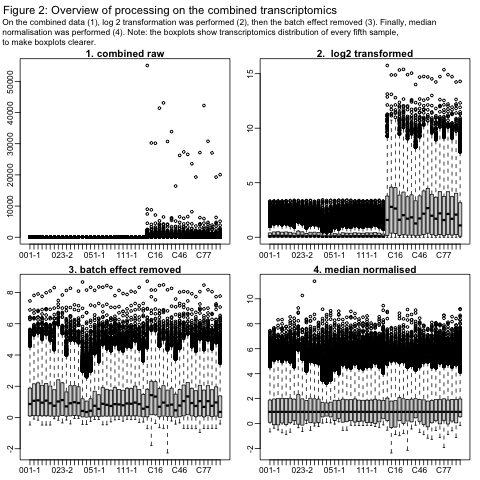

### 3.2.3 Train/test split

With our processed combined datasets, we performed a stratified train/test split on each paper. We were able to do this as the combined datasets kept sample names in the columns, which allowed reference to which paper the sample came from. This stratified train/test split was performed on the outcome (moderate/ severe) in order to ensure splits had roughly equal outcome proportions, with 80% of the data forming the training data.

### 3.2.4 Feature and classifier selection for each platform

For each platform, we used its training set to perform feature and classifier selection. Within a cross-validation loop, we divided the platform’s training set into 5 folds, reserving 1 as a test fold. We first performed feature ranking using the 4 training folds on the current iteration (see Figure 1). Note that we experimented with different feature selection methods (see below).

Using the selected method, we altered the number of top features (E.g., top 10, top 20, …). On each of these sets of features, we built classifiers and calculated the cross-validation accuracy and recall, by cross-validating using the test fold. Cross validation was repeated 50 times.

### 3.2.5 Feature selection methods

We compared three feature selection approaches: moderated t-statistics, log fold-change, and a principal component-based approach.(PCA) Moderated t-statistics and log fold-change are commonly used in omics analysis to measure a feature’s expression difference.

However, one weakness of the moderated-t approach in the context of this project was that there remained many features with significant differential expression, even after adjusting for multiple testing. For example, out of the 600 metabolites, 133 had significant differential expression; even worse, out of the 16404 transcriptomes, 9454 had differential expression.

Hence, our third approach was to further differentiate the differentially expressed features using PCA. We perform PCA on the differentially expressed features, ranking them based on their absolute loadings in the first PC. This can be thought of as further ranking the differentially expressed features by how much they contribute to the first PC. For a detailed explanation, see the appendix.

### 3.2.6 Prevalidation

The previous section provided cross-validation accuracy and recall over 50 repetitions for each (model, set of features) combination.

Briefly put, prevalidation is a form of extreme variable reduction in omics data. It is necessary here because our final models combine clinical variables with the omics platforms (features numbering in the hundreds). If we simply modelled on the two, the features from the omics platforms would dominate the clinical ones. Hence, we use modelling to predict the outcomes (moderate/severe) for each platform, and this vector of outcomes is the prevalidated vector which we used in place of the features.

That being said, for each platform, we have three prevalidated vectors. We performed majority voting on the three prevalidated vectors to obtain a final prevalidated vector (see Figure 3).

The idea of using the majority voting comes from ensemble learning, which utilises multiple learning algorithms for better performance than one individual algorithm alone. Theoretically, if combined, the majority vote of the three with roughly the same performance should be more accurate than a single prediction. Further, 3 is an odd number, which was chosen so that ties in voting would not be broken arbitrarily. In this way, we may stabilise the prevalidated vectors and reduce the impact of overfitting for one individual classifier.

## 3.3 Final models

We built the final models by combining the final prevalidated vectors with the clinical variables. These are discussed in Results.

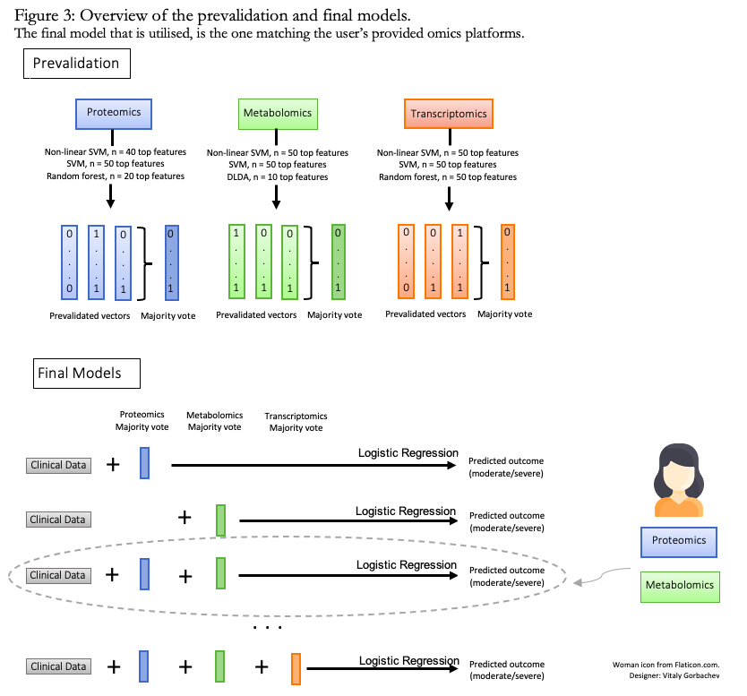

# 4 Results

## 4.1 Feature and classifier selection

To compare the performance of different combinations of features and classifiers in the feature selection step, we used recall as an evaluation metric on top of accuracy. In the context of a risk calculator, we are not just concerned with being accurate, but also being able to correctly identify every actual severe case (since these are potentially life-threatening).

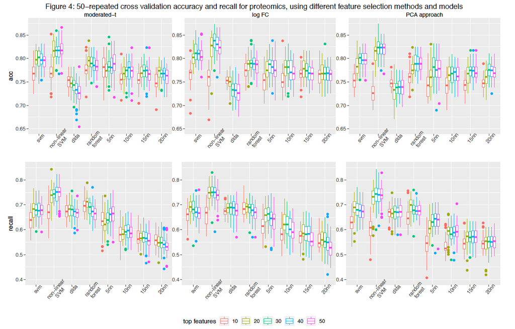

For proteomics, we observed that non-linear SVM is consistently the best model in terms of accuracy and recall. The combinations (SVM, n= 50) and (Random Forest, n= 20) also performed decently. Thus these 3 classifiers (including (non-linear SVM,n=40)) were chosen for proteomics. And as mentioned in the methods section, these classifiers were used to produce 3 prevalidated vectors, on which we perform a majority vote to create a final prevalidated vector.

The same procedure was performed for the other two platforms. For metabolomics, the best models had similar accuracy and recall as the proteomics. The best 3 metabolomics models we chose were (SVM, n = 50), (non-linear SVM, n= 50), (DLDA, n =10). For transcriptomics, the best models were (SVM, n = 50), (non-linear SVM, n= 50), (Random Forest, n =50). However, their performance was slightly worse: accuracy was about 75% with recall just over 60%.

## 4.2 Final models

We combined the proteomics, metabolomics and transcriptomics final prevalidated vectors with the clinical variables (age, gender) to build a logistic regression model. Age and gender were the common clinical variables from the four papers, hence being chosen.

One problem here was that since we had merged different datasets for each platform, we got a different set of samples for every platform. We resolved this by taking all the common samples of the three platforms in the prevalidation vectors.

To evaluate the model, we used 50-repeated 5-fold cross-validation as well as validating the model on the test dataset for Su. In Figure 5 below, the left box plot shows 50 repeated cross-validation accuracy and recall; the right table is the confusion matrix from validation on the test set. The CV accuracy and recall are about 0.85 and 0.75 on the training set. For the test set, validated performance is still good, with 0.96 accuracy and 0.89 recall.

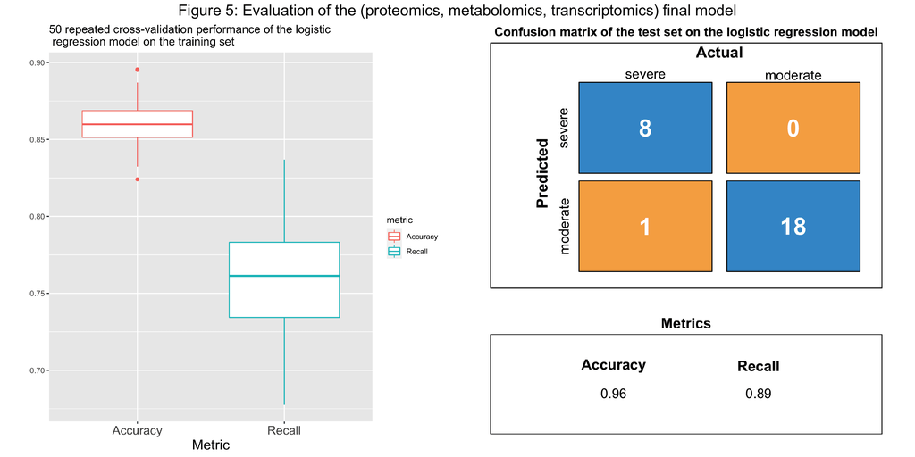

Based on the out-of-sample performance, we can expect the model to make fairly accurate predictions on new data.

However, we also consider if a user does not have omics data for all three platforms. For example, if a user only has proteomics and metabolomics, our product should also be able to adapt and make predictions based on these two platforms.

We also evaluated the logistic regression models built on every combination of platforms. For most models, the CV accuracies and recalls are around 0.85 and 0.75 respectively. One exception was the model only using the transcriptomics, with only 75% accuracy and 54% recall. The result coincides with what we derived from the feature selection step. The details of the evaluation can be seen in the Appendix.

## 4.3 Product

We deployed the above models in the shiny app. The link to the app is in the appendix. The app consists of two main parts: 1. Where users can explore our omics datasets. 2. Where users can upload their own datasets and obtain the predicted outcome using our models. In the “Data” tab, for each platform, there is a table ranking all the features (proteins/ metabolomics/ genes) by moderate t-statistic. There is a hyperlink on the feature names, directing users to a website containing information about the feature. The differential expression of each specific feature is also shown in a box plot and the user can choose which feature they want to look at. In addition, a set of features can be selected to explore whether the severe and moderate group are split in the PCA plot. In the “Prediction” tab, the user can upload their own datasets from available platforms under the instruction. The predicted outcome for each sample provided will be shown in one table. Note that as we introduced above, the prediction can still be made even if the user only provides one or two platforms.

# 5 Discussion

As mentioned in Feature Selection Methods, there were 9454 transcriptomes with significant differential expression. However, we only considered the top 10 to top 50 during our feature selection, due to computational complexity (each feature selection loop takes about 20 minutes to complete on a single machine). This helps explain why the transcriptomics-only final model performed the worst - we could not consider a larger set of significant transcriptomes. Future studies could look into parallel processing to process all the significant transcriptomes.

The four integrated datasets used different measures of moderate/severe COVID-19 outcome. For example, Su used the WHO ordinal scale, while Shen used the Chinese Government Diagnosis and Treatment Guideline. Future studies could look to integrate papers using the same standardised measure.

Another limitation of the risk calculator is that user uploaded datasets need to be cleaned before use and can only use features already in our model. Finally, our risk calculator was only trained on moderate and severe samples, hence it is only suitable for a patient who does indeed turn out moderate or severe. For healthy or mild patients, the risk calculator’s prediction is not trustworthy.

# 6 Conclusion

We have developed a risk calculator by integrating proteomics, metabolomics and transcriptomics data from different papers. The risk calculator adapts to any combination of these platforms the user provides - hence it is more widely applicable than a risk calculator only accepting one platform.

Future studies might consider a larger number of significant transcriptomes, and other omics platforms (e..g genomics), as these might produce better outcome classification.

# 7 Student Contributions

**Abdullah:** At the beginning, I gathered all relevant data from Su et al., created a git repository and uploaded the data and initial processing files there. Subsequently, I also collected all relevant data from the other papers and uploaded these to git too. I worked as a scribe by setting up and adding notes to the weekly presentations in addition to the weekly canvas discussion boards. I organised and attended zoom meetings and all tutorials to discuss the shiny app and processing methods. I assisted with writing, editing and formatting the report, presentation, and added textual information to the shiny app.

**Benjamin:** I helped Abdullah with the initial data collection for all 4 papers, worked with Rohen on the presentation slides and wrote scripts for everyone, highlighted challenges and problems for our project’s progression along with the rest of the team during tutorials and Zoom meetings, participated actively in taking the report through several editions and rewrites, and contributed to the final shiny app’s presentation and flair by writing up documentation as per Jean’s feedback, as well as working on the data along with everyone else, of course.

**Rohen:** I worked together with Youheng to process and integrate the data from different papers. I also created the early version of the feature and model selection, as well as the early version of the Shiny app (containing the prediction tab with underlying final models). I also assisted with the prevalidation and the final model design. For the report, I created and saved the majority of the Figures, as well as being a major contributor for writing the report. For reproducibility, I also cached all the heavy computations within our code, and helped Youheng with documentation.

**Ruilin:** During the early stage, I pre-processed transcriptomics data and built baseline models using the pre-processed data. To assist team members in integrating protein data from different datasets, I wrote a python script to scrape related information from Gencards.org. I also experimented with different types of imputation methods.

**Youheng:** I participated in the model design part, including feature selection and final model. Rohen and I preprocessed and integrated the datasets from different papers. I collected the codes for the final model and did Model evaluation. I wrote the major part of the shiny app for the data exploration tab. Based on Rohen’s work, I finalized the prediction tab as well. In addition, I went through the whole code and wrote some comments as well as a code documentation.

# 8 References

Overmyer et al. (2021). Large-Scale Multi-omic Analysis of COVID-19 Severity. Cell Systems, 12(1), 23-40, DOI: https://doi.org/10.1016/j.cels.2020.10.003

Patel et al. (2021). Proteomic Blood Profiling in Mild, Severe, and Critical COVID-19 Patents. MedRxiv. DOI: https://doi.org/10.1038/s41598-021-85877-0

Shen et al. (2020). Proteomic and Metabolomic Characterization of COVID-19 Patient Sera. Cell, 182(1), 59-72. DOI: https://doi.org/10.1016/j.cell.2020.05.032

Su et al. (2020). Multi-Omics Resolves a Sharp Disease-State Shift between Mild and Moderate COVID-19. Cell, 183(6), 1479-1495 DOI: https://doi.org/10.1016/j.cell.2020.10.037

R Core Team (2020). R: A language and environment for statistical computing. R Foundation for Statistical Computing, Vienna, Austria. URL https://www.R-project.org/.

Python Software Foundation. Python Language Reference, version 2.7. Available at http://www.python.org

Leek JT, Johnson WE, Parker HS, Fertig EJ, Jaffe AE, Zhang Y, Storey JD, Torres LC (2021). sva: Surrogate Variable Analysis. R package version 3.40.0.

Max Kuhn (2020). caret: Classification and Regression Training. R package version 6.0-86. https://CRAN.R-project.org/package=caret

Monn, D. (2021). Denoising Autoencoders explained. Retrieved 19 May 2021, from https://towardsdatascience.com/denoising-autoencoders-explained-dbb82467fc2

Denoising Autoencoders explained. https://towardsdatascience.com/denoising-autoencoders-explained-dbb82467fc2

# 9 Appendix

## 9.1 Shiny app link

https://github.com/LionelYao/Covid_C1_shinyapp

## 9.2 Code availability/ reproducing figures

The code including the data is too large (about 600MB). You can find the data and Rmd files in the following github repository:https://github.sydney.edu.au/asaf8323/covid_c1_data3888

Since our code is quite long and involves a lot of steps and heavy computation, it is stored in the Rmd files. A documentation about the code is written in code_documentation.txt. Basically, our project follows the following order:

We cleaned the four datasets in Processing_su_shen.Rmd and Processing_patel_jaitovitch.rmd. They are combined in “combined_data.Rmd”. The feature selection and prevalidation are done in “feature_selection.Rmd” and “prevalidation.Rmd”. The final logistic regression models and model evaluation are in “Final_models.Rmd”. The intermediate results are cached for each Rmd.

Report figures are also made in these Rmd files:

- Figure 1 was drawn in Microsoft Word and stored as png.
- Figure 2 was produced in chunk 17 of “combine_data.Rmd”. You need to run all the above code to reproduce it. The libraries required are listed at the end. Intermediate results stored in RDS files need to be downloaded.
- Figure 3 was drawn in Microsoft Word and stored as png.
- Figure 4 was produced in chunk 9 of “Feature_Selection.Rmd”. You need to run all the above code to reproduce it. Note that one subplot takes a few minutes to execute the 50 repeated CV and it takes about 20 minutes to execute the results produced from chunk 1 to chunk 8. Hene we cached the result of the function model_topn_cv_visualise() and model_topn_cv_visualise_recall() as RDS files.
- Figure 5 was a combination of 2 plots which were produced in “Final_models.Rmd”. The left plot was produced in chunk 21 and the right plot was produced in chunk 29. You need to run all the above code to reproduce it. Note that the 2 plots are stored into separate png images and then combined into one plot in chunk 30.

## 9.3 Shen et al. data

For the purposes of their study, the mild and typical groups were classed as moderate, and the severe and critical groups were classed as severe, containing 37 and 18 patients respectively. In their analysis, they split the dataset and used only 18 moderate and 13 severe cases to create their model, with the rest being used for validation and testing. The dataset that we obtained and used for our project only contained these 31 training cases.

## 9.4 Chinese Government Diagnosis and Treatment Guideline (Trial 5th version)

Shen et al. used this guideline to determine severity. The classes were: mild (no pneumonia symptoms), typical (fever or respiratory tract symptoms with pneumonia), severe (fulfilling any of the three criteria: respiratory rate ≥ 30 times/min OR mean oxygen saturation ≤ 93% in resting state OR arterial blood oxygen partial pressure/oxygen concentration ≤ 300 mmHg), and critical (going into shock OR respiratory failure and requiring mechanical ventilation OR admission to intensive care with any organ failure).

## 9.5 PCA-based feature selection

Principal-components analysis (PCA) is a method of dimension reduction, whereby a large number of features are summarised into a smaller set of variables known as principal components. Each principal component is a linear combination of the pre-existing features; for a given feature, its coefficient in a given principal component is known as its “loading”. The first principal component summarises the largest proportion of variance amongst the principal components. Hence the PCA-based feature selection used in the project is to rank features by their absolute loading in the first principal component. Roughly speaking these loadings can be seen as how much a feature contributes to the first principal component, with a larger loading meaning it is more important.

## 9.6 Validation of final models using test sets

To validate the two and three-omic final models, we used the test set from Su. This is because Patel, Shen and Overmyer each provide only one omics platform, and so using them in this instance would result in test samples of unequal dimension.

However, for the one-omic models, the test sets are the combined test set for that platform, i.e. Su+Patel for proteomics, Su+Shen for metabolomics, Su+Overmyer for transcriptomics.

Table 1 summarises the validation results.

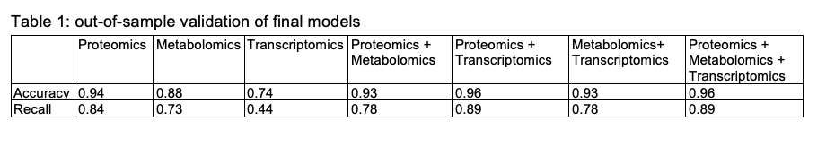

## 9.7 Data sources for each paper

- Overmyer et al. : The transcriptomics data was downloaded from the original paper published on cell.com, doi: https://doi.org/10.1016/j.cels.2020.10.003
- Shen et al. : The relevant metabolomics data was downloaded from the original paper published on cell.com, doi: https://doi.org/10.1016/j.cell.2020.05.032
- Su et al. : The single-cell RNA data was downloaded from Array Express with the code: E-MTAB-9357. Proteomics and Metabolomics data were downloaded from Mendeley Data, V4, doi: 10.17632/tzydswhhb5.4
- Patel et al. : Proteomics data was downloaded from BioStudies database, using S-BSST416 as accession number.